# Investigando os dados

Eric Gorgens

1/17/2021

Nosso primeiro desejo ao receber os dados é partir para a análise estatística. Mas espere! Antes de partir para uma análise de variância e teste de média, explore seus dados através dos diferentes pacotes gráficos disponíveis no R. Neste livro ficaremos com dois tipos de gráficos disponíveis no pacote básico do R:

- plot
- boxplot

Para quem busca opções avançadas para construção e gráficos recomendamos os pacotes:

- lattice: http://www.statmethods.net/advgraphs/trellis.html
- ggplot2: http://docs.ggplot2.org/current/

## Plot: Gráfico de dispersão

A função plot() é indicada para analisar duas variáveis quantitativas, já que uma assumirá o eixo x e outra o eixo y, sendo ambos os eixos numéricos e contínuos. Para exemplificar o uso das funções gráficas, utilizaremos os dados de um experimento sobre o aparecimento de brotos em função do mês em que a poda é realizada. Deseja-se encontrar em qual mês que a poda deve ser realizada visando minimizar o número de brotos.

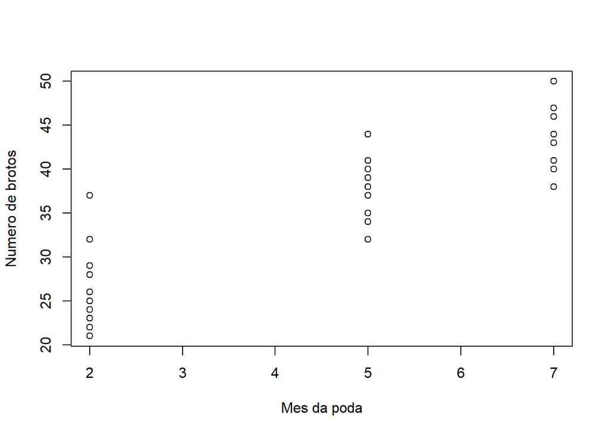

```r
exp.grafico = read.csv("./data/Exemplo para Graficos.csv", sep = ",", dec = ".")
plot(data = exp.grafico, Brotos ~ MesPoda, xlab = "Mes da poda",
     ylab = "Numero de brotos")
```

A interpretação de um gráfico de dispersão é bastante intuitiva e direta. Em geral, no eixo X (horizontal) coloca-se a variável que espera-se influenciar de alguma maneira a variável que está no eixo Y (vertical). Desta maneira, analisa-se o quanto a variável do eixo X está influenciando a variável do eixo Y. No exemplo apresentado acima, a nossa variável mês de poda, influencia positivamente o número de brotos. Uma vez que quanto maior o mês de poda, maior é o número de brotos. Neste caso, estamos observando uma relação diretamente proporcional.

## Boxplot: Gráfico de caixas

A função boxplot() é indicada para analisar uma variável categórica e outra variável contínua. Situação ideal, por exemplo, para verificar a influência de tratamentos qualitativos sobre uma variável de interesse. Ou ainda, avaliar o efeito do bloco sobre a variável de interesse.

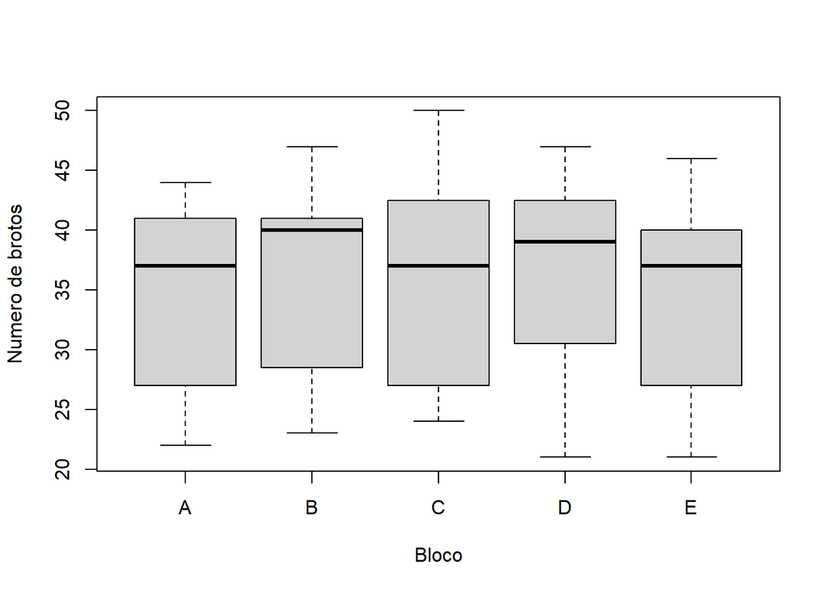

```r
exp.grafico = read.csv("./data/Exemplo para Graficos.csv", sep = ",", dec = ".")
boxplot(data = exp.grafico, Brotos ~ Bloco, xlab = "Bloco",
        ylab = "Numero de brotos")
```

A interpretação do boxplot pode parecer complicada, já que este gráfico apresenta uma série de informações estatísticas em um único gráfico. Mas é justamente esta característica que torna este gráfico tão utilizado e tão importante.

Existem variações do boxplot considerando diferentes estatísticas na sua construção, mas vamos ficar com a estrutura clássica formada por uma linha horizontal, dentro de uma caixa, sobreposta a uma linha vertical (do inglês whisker, também conhecida como fios do bigode).

A linha horizontal no interior da caixa indica a mediana, ou o segundo quartil. Os limites da caixa indicam o primeiro e o terceiro quartil. Os fios do bigode (ou whiskers) indicam o máximo e o mínimo, excluindo outliers. No exemplo que apresentamos acima, não houve a presença de outliers. A função boxplot assume como outlier dados que estão acima ou abaixo de 1.5 vezes a distância inter-quartil. Estes pontos considerados *outlier* serão marcadas pontualmente no gráfico.

O gráfico criado com a função boxplot() não remove os outliers, apenas exibe no gráfico. Assim, cabe a você a decisão de removê-los ou não.